# mnist_example_q1

Kristof Menyhert

02.06.2018

## Example of DeepLearning in R: Classifying handwritten numbers

In this example I am training a deep learning model using R, Keras and TensorFlow for classifying handwritten numbers.

Setting up the environment:

```r
library(keras)
```

MNIST is a build in dataset to keras, so I am loading it. Also, I am splitting the data into train and test sets.

```r
c(c(x_train, y_train), c(x_test, y_test)) %<-% dataset_mnist()
```

See an example of the actual data we have:

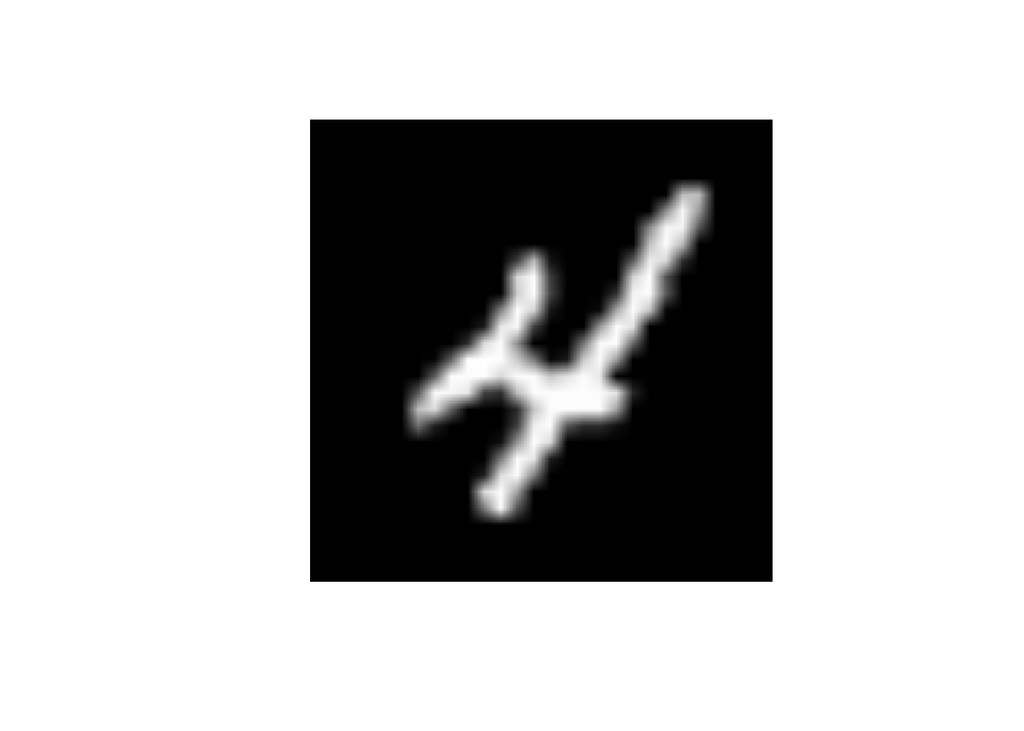

```r
plot(as.raster(x_train[10,,], max = 255))
```

Reshape the data: * Flatten images and transform RGB values into [0,1] range * dim() can’t be used, use reshape instead

```r
x_train <- array_reshape(x_train, c(nrow(x_train), 784))
x_test <- array_reshape(x_test, c(nrow(x_test), 784))
```

Scale the data, since numbers are big and we need smaller numbers to be able to run our model.

```r
x_train <- x_train / 255
x_test <- x_test / 255
```

One hot encoding of our target (y) variable <- Convert class vectors to binary class matrices

```r
y_train <- to_categorical(y_train, 10)
y_test <- to_categorical(y_test, 10)
```

```r
model <- keras_model_sequential()  %>%
  layer_dense(units = 256, activation = 'relu', input_shape = c(784)) %>%
  layer_dropout(rate = 0.4) %>%
  layer_dense(units = 128, activation = 'relu') %>%
  layer_dropout(rate = 0.3) %>%
  layer_dense(units = 64, activation = 'relu') %>%
  layer_dropout(rate = 0.2) %>%
  layer_dense(units = 10, activation = 'softmax') #activation function should be used with the deffined loss function


model %>% compile(
  loss = 'categorical_crossentropy',
  optimizer = optimizer_rmsprop(),
  metrics = c('accuracy')
)
```

Let’s inspect our model:

```r
summary(model)
```

```
## ___________________________________________________________________________
## Layer (type)                     Output Shape                  Param #
## ===========================================================================
## dense_1 (Dense)                  (None, 256)                   200960
## ___________________________________________________________________________
## dropout_1 (Dropout)              (None, 256)                   0
## ___________________________________________________________________________
## dense_2 (Dense)                  (None, 128)                   32896
## ___________________________________________________________________________
## dropout_2 (Dropout)              (None, 128)                   0
## ___________________________________________________________________________
## dense_3 (Dense)                  (None, 64)                    8256
## ___________________________________________________________________________
## dropout_3 (Dropout)              (None, 64)                    0
## ___________________________________________________________________________
## dense_4 (Dense)                  (None, 10)                    650
## ===========================================================================
## Total params: 242,762
## Trainable params: 242,762
## Non-trainable params: 0
## ___________________________________________________________________________
```

- The model has 242,762 parameters
- we need to train this many weights
- We have 7 layers

Run the model, use early stopping (the command callbacks()):

```r
history <- model %>% fit(
  x_train, y_train,
  batch_size = 58, #higher takes shorter to run
  epochs = 10, #shufle the order, but take the dataset
  callbacks = list(
    callback_early_stopping(patience = 3)),
  validation_split = 0.2
)
```

Plot the results of our model:

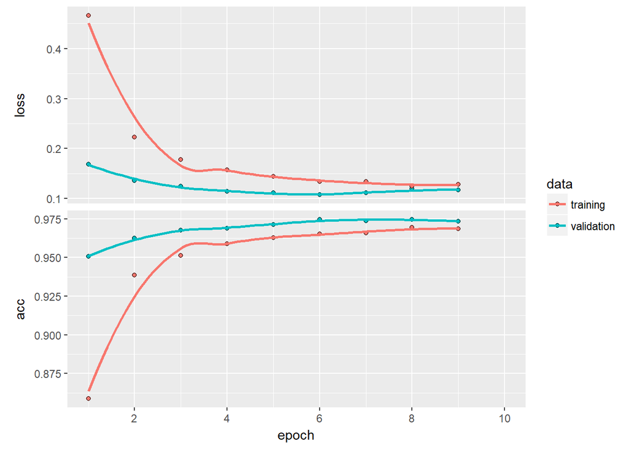

```r
plot(history)
```

Evaluate our model on the test set:

```r
model %>% evaluate(x_test, y_test)
```

```
## $loss
## [1] 0.1026132
##
## $acc
## [1] 0.9762
```

- we have loss arond: 0.1
- and accuracy more than 0.97

Predict our results:

```r
y_test[1:20,]
```

```
##       [,1] [,2] [,3] [,4] [,5] [,6] [,7] [,8] [,9] [,10]
##  [1,]    0    0    0    0    0    0    0    1    0     0
##  [2,]    0    0    1    0    0    0    0    0    0     0
##  [3,]    0    1    0    0    0    0    0    0    0     0
##  [4,]    1    0    0    0    0    0    0    0    0     0
##  [5,]    0    0    0    0    1    0    0    0    0     0
##  [6,]    0    1    0    0    0    0    0    0    0     0
##  [7,]    0    0    0    0    1    0    0    0    0     0
##  [8,]    0    0    0    0    0    0    0    0    0     1
##  [9,]    0    0    0    0    0    1    0    0    0     0
## [10,]    0    0    0    0    0    0    0    0    0     1
## [11,]    1    0    0    0    0    0    0    0    0     0
## [12,]    0    0    0    0    0    0    1    0    0     0
## [13,]    0    0    0    0    0    0    0    0    0     1
## [14,]    1    0    0    0    0    0    0    0    0     0
## [15,]    0    1    0    0    0    0    0    0    0     0
## [16,]    0    0    0    0    0    1    0    0    0     0
## [17,]    0    0    0    0    0    0    0    0    0     1
## [18,]    0    0    0    0    0    0    0    1    0     0
## [19,]    0    0    0    1    0    0    0    0    0     0
## [20,]    0    0    0    0    1    0    0    0    0     0
```

```r
model %>% predict_classes(x_test[1:20,])
```

```
##  [1] 7 2 1 0 4 1 4 9 5 9 0 6 9 0 1 5 9 7 3 4
```